# 1. Loading Data

# 2. Data Imputation

# 3. Exploratory Data Analysis

# 4. Feature Engineering

# 5. Feature Selection

## 5.1 Numerical Features

## 5.2 Categorical Features

# 6. Modelling

## 6.1 Modelling with missing values in Revenue

### 6.1.1 Linear Regression

### 6.1.2 Random Forest

### 6.1.3 XGBoost

### 6.1.4 Lightgbm

## 6.2 Modelling with filled values in Revenue

### 6.1.1 Linear Regression

### 6.1.2 Random Forest

### 6.1.3 XGBoost

### 6.1.4 Lightgbm

# 7. Summary of models

# 8. Conclusion

## Importing all required libraries

```python
import pandas as pd
from itertools import *
import matplotlib.pyplot as plt
import seaborn as sns
%matplotlib inline
import numpy as np
import plotly.offline as py
py.init_notebook_mode(connected=True)
import plotly.graph_objs as go
import plotly.tools as tls
import plotly.express as px
from collections import Counter
import ast
import gc
import datetime
import holidays
from datetime import date
from scipy.stats import chi2_contingency
from scipy.stats import chi2
from scipy.stats import pearsonr
from scipy import stats
from sklearn.model_selection import train_test_split
from sklearn.ensemble import RandomForestClassifier
from sklearn.ensemble import RandomForestRegressor
import xgboost as xgb
from sklearn.metrics import accuracy_score, mean_squared_error
from xgboost import XGBClassifier
from xgboost.sklearn import XGBRegressor
from math import sqrt
from bayes_opt import BayesianOptimization
from sklearn.model_selection import cross_val_score
from lightgbm import LGBMRegressor
import lightgbm as lgb
import warnings
warnings.simplefilter(action='ignore', category=FutureWarning)
import gc
```

# 1. Loading Data

Lets load the data and extract some basic information about dataset

```python
main_data = pd.read_csv("Movie_Revenue_predictions.csv", parse_dates=['release_date'])
print(f"we have {main_data.shape[0]} rows and {main_data.shape[1]} columns in our dataset \n")
main_data.head(3)
```

```
we have 4803 rows and 16 columns in our dataset
```

|  | title | tagline | revenue | budget | genres | homepage | id | keywords | original_language | overview | production_companies | production_countries | release_date | runtime | spoken_languages | status |
| --- | --- | --- | --- | --- | --- | --- | --- | --- | --- | --- | --- | --- | --- | --- | --- | --- |
| 0 | Avatar | Enter the World of Pandora. | 2787965087 | 237000000 | [{"id": 28, "name": "Action"}, {"id": 12, "nam... | http://www.avatarmovie.com/ | 19995 | [{"id": 1463, "name": "culture clash"}, {"id":... | en | In the 22nd century, a paraplegic Marine is di... | [{"name": "Ingenious Film Partners", "id": 289... | [{"iso_3166_1": "US", "name": "United States o... | 2009-12-10 | 162.0 | [{"iso_639_1": "en", "name": "English"}, {"iso... | Released |
| 1 | Pirates of the Caribbean: At World's End | At the end of the world, the adventure begins. | 961000000 | 300000000 | [{"id": 12, "name": "Adventure"}, {"id": 14, "... | http://disney.go.com/disneypictures/pirates/ | 285 | [{"id": 270, "name": "ocean"}, {"id": 726, "na... | en | Captain Barbossa, long believed to be dead, ha... | [{"name": "Walt Disney Pictures", "id": 2}, {"... | [{"iso_3166_1": "US", "name": "United States o... | 2007-05-19 | 169.0 | [{"iso_639_1": "en", "name": "English"}] | Released |
| 2 | Spectre | A Plan No One Escapes | 880674609 | 245000000 | [{"id": 28, "name": "Action"}, {"id": 12, "nam... | http://www.sonypictures.com/movies/spectre/ | 206647 | [{"id": 470, "name": "spy"}, {"id": 818, "name... | en | A cryptic message from Bond’s past sends him o... | [{"name": "Columbia Pictures", "id": 5}, {"nam... | [{"iso_3166_1": "GB", "name": "United Kingdom"... | 2015-10-26 | 148.0 | [{"iso_639_1": "fr", "name": "Fran\u00e7ais"},... | Released |

# 2. Data Imputation

Imputing missing values in overview, release_date, runtime columns

```python
print("\nlets take a look at missing and see if we can fill those")

x = datetime.datetime(2015, 1, 4)
main_data.loc[main_data['id'] == 380097,'release_date'] = x
main_data.loc[main_data['id'] == 370980,'runtime'] = 113
main_data.loc[main_data['id'] == 459488,'runtime'] = 81
main_data.loc[main_data['id'] == 370980,'overview'] = "The life of Jorge Mario Bergoglio, from his youth to his election as head of the Roman Catholic Church."
main_data.loc[main_data['id'] == 459488,'overview'] = "An exploration of how singer and actor Frank Sinatra became one of the biggest stars of the 20th century while remaining, in his heart, a normal person."
main_data.loc[main_data['id'] == 292539,'overview'] = "Farmworkers in Immokalee, Fla., launch a hunger strike at the headquarters of Publix supermarkets to protest poor wages and working conditions."

#we have successfully filled the missing values in release date, runtime and overview column
print("\n\n")
print(main_data.isnull().sum()) ##

##making a copy of dataset
moviedata = main_data.copy()
```

```
lets take a look at missing and see if we can fill those



title                      0
tagline                  844
revenue                    0
budget                     0
genres                     0
homepage                3091
id                         0
keywords                   0
original_language          0
overview                   0
production_companies       0
production_countries       0
release_date               0
runtime                    0
spoken_languages           0
status                     0
dtype: int64
```

# 3. Exploratory Data Analysis

Before doing EDA we need to process below columns:

1. release_date (some of the release date are from future)
2. genres (dictionary form)
3. production companies (dictionary form)
4. production countries (dictionary form)
5. keywords (dictionary form)
6. spoken languages (dictionary form)

```python
def preprocessing(df):


    ##lets correct the release date and extract year, month, day and day of week in separate columns
    def correcting_dates(df):
        df['release_year'] = df['release_date'].dt.year
        df['release_month'] = df['release_date'].dt.month
        df['release_day'] = df['release_date'].dt.day
        df['release_quarter'] = df['release_date'].dt.quarter
        df.drop(columns=['release_date'], inplace=True)
        df['release_year']=np.where(df['release_year']> 2019, df['release_year']-100, df['release_year'])
        year = df["release_year"].astype(int).copy().astype(str)
        month=df['release_month'].astype(int).copy().astype(str)
        day=df['release_day'].astype(int).copy().astype(str)
        df["release_date"]=  month.str.cat(day.str.cat(year,sep="/"), sep ="/")
        df['release_date']=pd.to_datetime(df['release_date'],format="%m/%d/%Y")
        df['release_dow'] = df['release_date'].dt.dayofweek
        return df

    df = correcting_dates(df)


    ##for genres column

    df['genres'] = df['genres'].apply(lambda x: {} if pd.isna(x) else ast.literal_eval(x) )


    ##production companies
    df['production_companies'] = df['production_companies'].apply(lambda x: {} if pd.isna(x) else ast.literal_eval(x) )




    ## production countries
    df['production_countries'] = df['production_countries'].apply(lambda x: {} if pd.isna(x) else ast.literal_eval(x) )

    ## keywords
    df['keywords'] = df['keywords'].apply(lambda x: {} if pd.isna(x) else ast.literal_eval(x) )

    ##spoken languages
    df['spoken_languages'] = df['spoken_languages'].apply(lambda x: {} if pd.isna(x) else ast.literal_eval(x) )


    return df


main_data = preprocessing(main_data)
```

```python
tmp = main_data['release_date'].value_counts().sort_index()

data = go.Histogram(x=tmp.index, y=tmp.values, name='all data')
layout = go.Layout(dict(title = "Counts of Movies",
                  xaxis = dict(title = 'Year'),
                  yaxis = dict(title = 'Count'),
                  ),legend=dict(
                orientation="v"))
py.iplot(dict(data=data, layout=layout))
```

[interactive chart not shown]

In the above plot we can see the year bias. we have very less movies released before 2000 as compare to movies realeased after 2000. Now lets compare the revenue and budget of old and new movies

[interactive chart not shown]

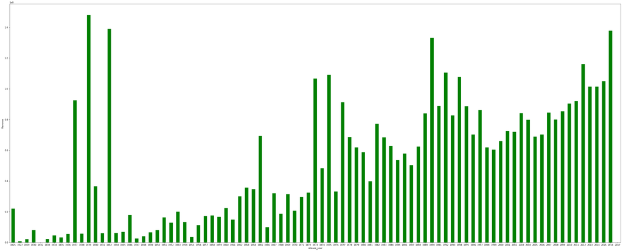

```python
fig = plt.figure(figsize=(50,20))
main_data.groupby('release_year').agg('mean')['revenue'].plot(kind='bar',color='g',rot=0)
plt.ylabel('Revenue')

d1 = main_data['release_year'].value_counts().sort_index()
d2 = main_data.groupby(['release_year'])['revenue'].mean()
data = [go.Scatter(x=d1.index, y=d1.values, name='film count'), go.Scatter(x=d2.index, y=d2.values, name='mean revenue', yaxis='y2')]
layout = go.Layout(dict(title = "Number of films and average revenue per year",
                  xaxis = dict(title = 'Year'),
                  yaxis = dict(title = 'Count'),
                  yaxis2=dict(title='Average revenue', overlaying='y', side='right')
                  ),legend=dict(
                orientation="v"))
py.iplot(dict(data=data, layout=layout))
```

In the above plot we are looking at the mean revenue of the movies per year. we can clearly see that revenue of the new movies(movies released after 2000)are alot more than the old movies(movies released before 2000) just because there are less old movies in our dataset and factors like increase in ticket prices over the years, promotions, increase in number of screens and digital platforms etc.  
In the above plot there are some spikes in the 30s so after investigating the revenue of movie named "Snow White and the Seven Dwarfs" (1937) was incorrect. we change with the correct one Source : https://en.wikipedia.org/wiki/Snow_White_and_the_Seven_Dwarfs_(1937_film)

```python
main_data.loc[main_data['id'] == 408,'revenue'] = 6500000
```

[interactive chart not shown]

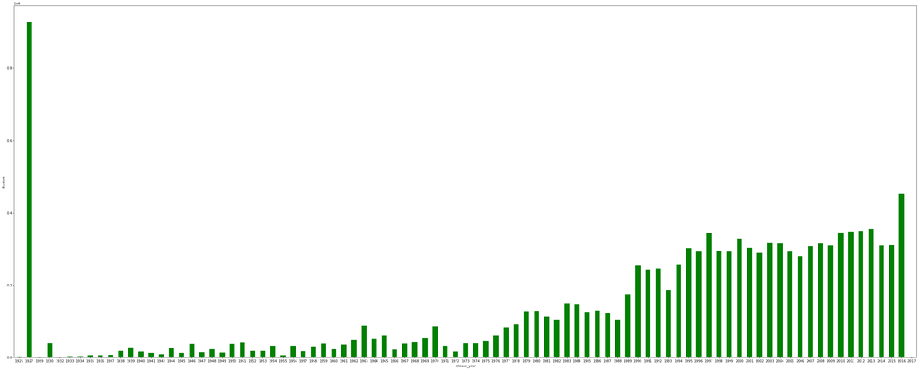

```python
fig = plt.figure(figsize=(50,20))
main_data.groupby('release_year').agg('mean')['budget'].plot(kind='bar',color='g',rot=0)
plt.ylabel('Budget')


d1 = main_data['release_year'].value_counts().sort_index()
d2 = main_data.groupby(['release_year'])['budget'].mean()
data = [go.Scatter(x=d1.index, y=d1.values, name='film count'), go.Scatter(x=d2.index, y=d2.values, name='mean revenue', yaxis='y2')]
layout = go.Layout(dict(title = "Number of films and average budget per year",
                  xaxis = dict(title = 'Year'),
                  yaxis = dict(title = 'Count'),
                  yaxis2=dict(title='Average budget', overlaying='y', side='right')
                  ),legend=dict(
                orientation="v"))
py.iplot(dict(data=data, layout=layout))
```

The mean budget per year has gradually increased over the years. Also there is surprisingly high mean budget in 1927. After investigating there is only one movie(Metropolis) released in 1927. But, still the budget of this movie was way up high for year 1927. The budget was 92 million in 1927 which is worth 210 million today. Even movies like "World War Z"(2013), "Amazing Spider Man 2"(2014), "Transformer : Age of Extinction"(2014), "Furious 7"(2015) were made in less than 210 million. So this is an anamoly in our dataset. we will replace the old budget with the new one (5.3 million) Source : https://en.wikipedia.org/wiki/Metropolis_(1927_film)

```python
main_data.loc[main_data['id'] == 19,'budget'] = 5300000
```

```python
d1 = main_data['release_dow'].value_counts().sort_index()
d2 = main_data.groupby(['release_dow'])['revenue'].mean()
data = [go.Scatter(x=d1.index, y=d1.values, name='movie count'), go.Scatter(x=d2.index, y=d2.values, name='mean revenue', yaxis='y2')]
layout = go.Layout(dict(title = "Number of films and average revenue per weekday",
                  xaxis = dict(title = 'weekday'),
                  yaxis = dict(title = 'Count'),
                  yaxis2=dict(title='Average revenue', overlaying='y', side='right')
                  ),legend=dict(
                orientation="v"))
py.iplot(dict(data=data, layout=layout))
#The day of the week with Monday=0, Sunday=6.
```

[interactive chart not shown]

The above plot is mean revenue of the movies per week day. For e.g the avg revenue of the movies released on wed is above 600 millions dollars.

```python
d1 = main_data['release_month'].value_counts().sort_index()
d2 = main_data.groupby(['release_month'])['revenue'].mean()
data = [go.Scatter(x=d1.index, y=d1.values, name='movie count'), go.Scatter(x=d2.index, y=d2.values, name='mean revenue', yaxis='y2')]
layout = go.Layout(dict(title = "Number of films and average revenue per month",
                  xaxis = dict(title = 'month'),
                  yaxis = dict(title = 'Count'),
                  yaxis2=dict(title='Average revenue', overlaying='y', side='right')
                  ),legend=dict(
                orientation="v"))
py.iplot(dict(data=data, layout=layout))
###  Jan=1, Dec=12.
```

[interactive chart not shown]

The above plot is mean revenue of the movies by month. For e.g the avg revenue of the movies released in june is above 700 millions dollars.

```python
d1 = main_data['release_day'].value_counts().sort_index()
d2 = main_data.groupby(['release_day'])['revenue'].mean()
data = [go.Scatter(x=d1.index, y=d1.values, name='movie count'), go.Scatter(x=d2.index, y=d2.values, name='mean revenue', yaxis='y2')]
layout = go.Layout(dict(title = "Number of films and average revenue per day of month",
                  xaxis = dict(title = 'day of month'),
                  yaxis = dict(title = 'Count'),
                  yaxis2=dict(title='Average revenue', overlaying='y', side='right')
                  ),legend=dict(
                orientation="v"))
py.iplot(dict(data=data, layout=layout))
```

[interactive chart not shown]

The above plot is mean revenue of the movies by day of the month. For e.g the avg revenue of the movies released on 25th day of the month is 600 millions dollars. we can say from the above plots that releasing movies on wednesday or in june or 25th day of the month would be a good idea but lets not jump to the conclusion yet we will investigate further.

```python
fig = px.scatter(main_data, x="runtime", y="revenue", color="release_year", hover_data=(['title','budget']))
fig.show()
```

[interactive chart not shown]

From the above plot it is clear that there is very low linear correlation between runtime and revenue. Also runtime has not change siginificantly over the years

```python
fig = px.scatter(main_data, x="budget", y="revenue", color="release_year", hover_data=(['title','runtime']))
fig.show()
```

[interactive chart not shown]

In the above plot we can see that there is linear relationship between budget and revenue if the budget increases then revenue also increases, But movies like "Pirates of the caribbean : on stranger tides"(right most point on plot) had spent most but did not have highest revenue. we can also easily point out blockbuster movies(Titanic, Avatar) from the above plot based on their revenue and budget. Also most of the movies with highest budget are released around 1990 or after 2000 due to growth of film industries.

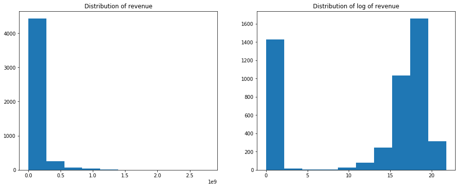

```python
fig, ax = plt.subplots(figsize = (16, 6))
plt.subplot(1, 2, 1)
plt.hist(main_data['revenue']);
plt.title('Distribution of revenue');
plt.subplot(1, 2, 2)
plt.hist(np.log1p(main_data['revenue']));
plt.title('Distribution of log of revenue');
#plt.savefig("logrevenue.png")
```

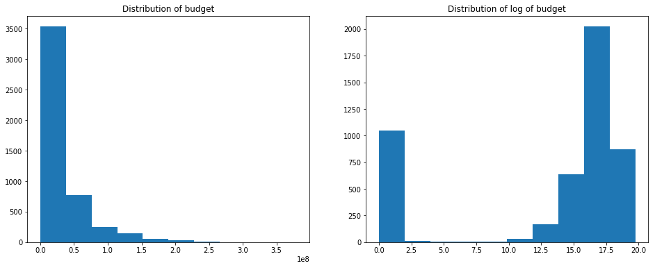

```python
fig, ax = plt.subplots(figsize = (16, 6))
plt.subplot(1, 2, 1)
plt.hist(main_data['budget']);
plt.title('Distribution of budget');
plt.subplot(1, 2, 2)
plt.hist(np.log1p(main_data['budget']));
plt.title('Distribution of log of budget');
#plt.savefig("logbudget.png")
```

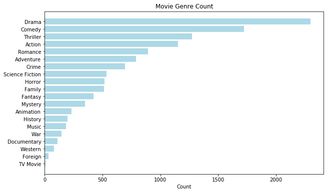

```python
list_of_genres = list(main_data['genres'].apply(lambda x: [i['name'] for i in x] if x != {} else []).values)
top_genres = Counter([i for j in list_of_genres for i in j]).most_common() #all possible genres
fig = plt.figure(figsize=(10, 6))
data=dict(top_genres)
names = list(data.keys())
values = list(data.values())

plt.barh(sorted(range(len(data)),reverse=True),values,tick_label=names,color='lightblue')
plt.xlabel('Count')
plt.title('Movie Genre Count')
plt.show()
```

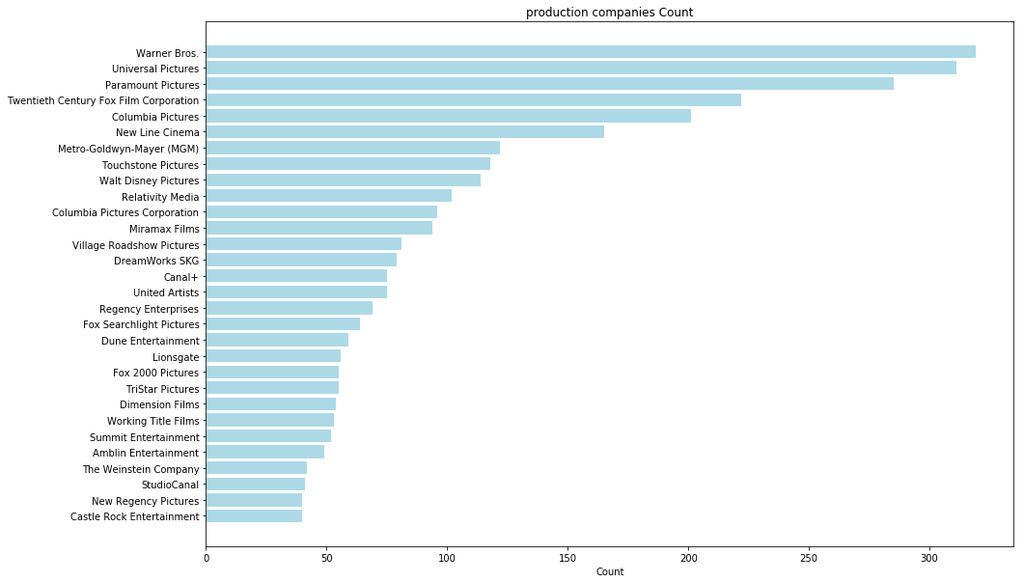

```python
list_of_companies = list(main_data['production_companies'].apply(lambda x: [i['name'] for i in x] if x != {} else []).values)
top_companies = Counter([i for j in list_of_companies for i in j]).most_common(30) #top 30 possible companies
fig = plt.figure(figsize=(15, 10))
data=dict(top_companies)
names = list(data.keys())
values = list(data.values())

plt.barh(sorted(range(len(data)),reverse=True),values,tick_label=names,color='lightblue')
plt.xlabel('Count')
plt.title('production companies Count')
plt.savefig('keywords.png')
plt.show()
```

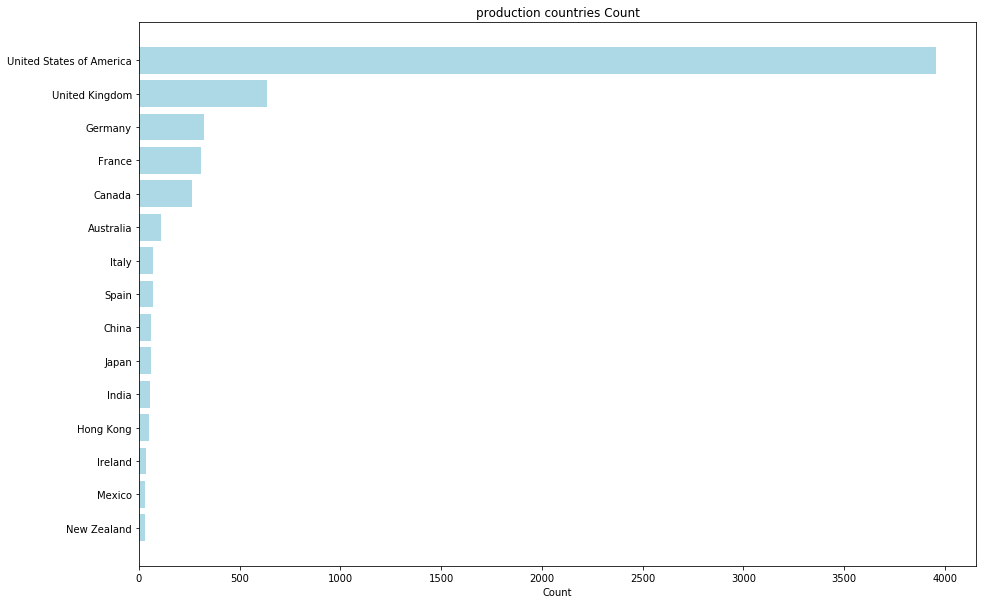

```python
list_of_countries = list(main_data['production_countries'].apply(lambda x: [i['name'] for i in x] if x != {} else []).values)
top_countries = Counter([i for j in list_of_countries for i in j]).most_common(15) #top 15 possible countries
fig = plt.figure(figsize=(15, 10))
data=dict(top_countries)
names = list(data.keys())
values = list(data.values())

plt.barh(sorted(range(len(data)),reverse=True),values,tick_label=names,color='lightblue')
plt.xlabel('Count')
plt.title('production countries Count')
plt.savefig('prodcountry.png')
plt.show()
```

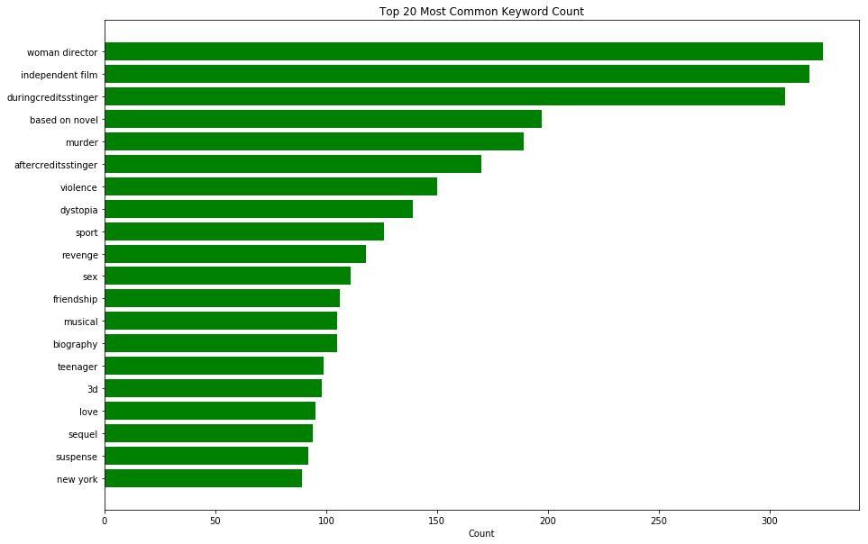

```python
list_of_keywords = list(main_data['keywords'].apply(lambda x: [i['name'] for i in x] if x != {} else []).values)
most_common_keywords=Counter([i for j in list_of_keywords for i in j]).most_common(20)

fig = plt.figure(figsize=(15, 10))
data=dict(most_common_keywords)
names = list(data.keys())
values = list(data.values())

plt.barh(sorted(range(len(data)),reverse=True),values,tick_label=names,color='green')
plt.xlabel('Count')
plt.title('Top 20 Most Common Keyword Count')
#plt.savefig('keywords.png')
plt.show()
```

# 4. Feature Engineering

Generating new additional features

```python
def feature_engineering(df):


    ##lets correct the release date and extract year, month, day and day of week in separate columns
    def correcting_dates(df):
        df['release_year'] = df['release_date'].dt.year
        df['release_month'] = df['release_date'].dt.month
        df['release_day'] = df['release_date'].dt.day
        df['release_quarter'] = df['release_date'].dt.quarter
        df.drop(columns=['release_date'], inplace=True)
        df['release_year']=np.where(df['release_year']> 2019, df['release_year']-100, df['release_year'])
        year = df["release_year"].astype(int).copy().astype(str)
        month=df['release_month'].astype(int).copy().astype(str)
        day=df['release_day'].astype(int).copy().astype(str)
        df["release_date"]=  month.str.cat(day.str.cat(year,sep="/"), sep ="/")
        df['release_date']=pd.to_datetime(df['release_date'],format="%m/%d/%Y")
        df['release_dow'] = df['release_date'].dt.dayofweek
        return df

    df = correcting_dates(df)

    ## title
    df['title_word_count'] = df['title'].str.split().str.len()

    ##for genres column

    df['genres'] = df['genres'].apply(lambda x: {} if pd.isna(x) else ast.literal_eval(x) )
    df['num_genres'] = df['genres'].apply(lambda x: len(x) if x != {} else 0) #summation of number of genres
    df['all_genres'] = df['genres'].apply(lambda x: ' '.join(sorted([i['name'] for i in x])) if x != {} else '') #all possible genres in one column\
    list_of_genres = list(df['genres'].apply(lambda x: [i['name'] for i in x] if x != {} else []).values) ##list of all genres in every row #20
    top_genres = [m[0] for m in Counter([i for j in list_of_genres for i in j]).most_common()] #we may create more sparse data using all genre
    for g in top_genres:

        df[ g + '_genre'] = df['all_genres'].apply(lambda x: 1 if g in x else 0)




    ## homepage
    df['has_homepage'] = 1
    df.loc[pd.isnull(df['homepage']) ,"has_homepage"] = 0



    ## tagline
    df['isTaglineNA'] = 0
    df.loc[df['tagline'] == 0 ,"isTaglineNA"] = 1
    df['tagline_word_count'] = df['tagline'].str.split().str.len()





    ##original language
    df['eng_language'] = 0
    df.loc[ df['original_language'] == "en" ,'eng_language'] = 1



    ##overview
    df['overview_word_count'] = df['overview'].str.split().str.len()


    ##production companies
    df['num_production_companies'] = df['production_companies'].apply(lambda x: len(x) if x != {} else 0)



    ## production countries
    df['num_production_countries'] = df['production_countries'].apply(lambda x: len(x) if x != {} else 0)

    ## spoken languages
    df['num_spoken_languages'] = df['spoken_languages'].apply(lambda x: len(x) if x != {} else 0)



    ## extra features
    df['meanruntimebyyear'] = df.groupby("release_year")["runtime"].transform('mean')



    ## number of clashes

    hit_movies = df[df['revenue'] >=  df.revenue.quantile(0.60)] #38 million
    hit_movies_dates = list(hit_movies['release_date'])
    hit_movies_title = list(hit_movies['title'])
    upp = pd.Timedelta('15 days')
    low = pd.Timedelta('-15 days')
    same = pd.Timedelta('0 days')

    def number_of_clashes(row):
        if row['title'] in hit_movies_title:
            a = 0
            return a
        else:

            for i in hit_movies_dates:
                ans = row['release_date'] - i
                num_clashes = 0
                if low <= ans <= upp:
                    num_clashes += 1
                else:
                    num_clashes += 0
                return num_clashes

    df['Num_clash'] = df.apply(lambda row : number_of_clashes(row), axis=1)



    ## binned release year into decades (binning helps)

    bins = [1920, 1930, 1940, 1950, 1960, 1970, 1980, 1990, 2000, 2010, 2020]
    labels = [1,2,3,4,5,6,7,8,9,10]
    df['binned_release_year'] = pd.cut(df['release_year'], bins=bins, labels=labels)


    ## BUDGET ##########################

    mean_budget_year = df.groupby("release_year")["budget"].mean()
    mean_budget_year_dict = mean_budget_year.to_dict()
    mean_budget_year_dict[1926] = 0
    mean_budget_year_dict[1932] = 0
    mean_budget_year_dict[1928] = 0
    mean_budget_year_dict[1931] = 0
    mean_budget_year_dict[1943] = 0
    mean_budget_year_dict[2017] = 0

    '''
      ******* NOT USED *******
    def filling_zero(row):
        if row['budget'] == 0:
            year = row['release_year']
            ans = mean_budget_year[year]
            return ans
        else:
            ans = row['budget']
            return ans
    df['budget'] = df.apply(lambda row : filling_zero(row), axis=1)

    '''
    df.drop([4255], inplace = True) ## this row was causing a problem.
    df['meanbudgetbyyear'] = df.groupby("release_year")["budget"].transform('mean')
    df['medianbudgetbyyear'] = df.groupby("release_year")["budget"].transform('median')

    #now binning budget
    bins = list(range(0,380000000, 5000000)) #1 bin = 5 mil
    labels = list(range(1,76,1))
    df['binned_budget'] = pd.cut(df['budget'], bins=bins, labels=labels)

    ##inflation budget over a year, so we will see rise in mean year budget with respect to first year mean budget in our dataset
    df['inflated_budget_year'] = df.apply(lambda row : (row['meanbudgetbyyear'] - 245000)/row['meanbudgetbyyear'] , axis=1)

    ##inflation budget over a decade, so we will see rise in mean decade budget with respect to first decade mean budget
    df['meanbudgetbydecade'] = df.groupby("binned_release_year")["budget"].transform('mean')
    df['inflated_budget_decade'] = df.apply(lambda row : (row['meanbudgetbydecade'] - 19514600)/row['meanbudgetbydecade'] , axis=1)

    ## inflation budget by last year
    def inflated_budget_last_year(row):
        if row['release_year'] == 1925:
            return 0
        else:
            a = row['release_year']
            if mean_budget_year_dict[a] == 0:
                return 0
            else:

                b = (row['release_year'] -1)
                ans = (mean_budget_year_dict[a] - mean_budget_year_dict[b]) / mean_budget_year_dict[a]
                return ans




    df['inflation_last_year'] = df.apply(lambda row : inflated_budget_last_year(row), axis=1)



    ## budget year ratio
    df['budget_year_ratio'] = df['budget'] / (df['release_year'] * df['release_year'])

    ##budget runtime ratio
    df['budget_to_runtime'] = df['budget'] / df['runtime']

    ##budget to mean year budget
    df['budget_to_mean_year'] = df['budget'] / df['meanbudgetbyyear']

    ## runtime to mean year
    df['runtime_to_meanruntime'] = df['runtime'] / df['meanruntimebyyear']

    ## log transform budget
    df['budget'] = np.log1p(df['budget'])  ## can also use np.log() bcoz we dont have tiny values and np.log(0) cause an error

    ## log revenue
    df['revenue'] = np.log1p(df['revenue'])

    '''
    ******* NOT USED *******
    ## cusumer price index
    import cpi
    main_data['adjusted_budget'] = main_data.apply(lambda x: cpi.inflate(x.budget, x.release_year), axis=1)
    '''



    ## movie released ?
    df['isMovieReleased'] = 1
    df.loc[ df['status'] != "Released" ,"isMovieReleased"] = 0

    ## CHECKING FOR HOLIDAY RELEASE
    #import holidays
    #from datetime import date
    us_holidays = holidays.UnitedStates()
    df['USholidayreleased'] = df['release_date'].apply(lambda x: 1 if x in us_holidays else 0)



    ##KEYWORDS
    df['num_Keywords'] = df['keywords'].apply(lambda x: len(x) if x != {} else 0)
    df['keywords'] = df['keywords'].apply(lambda x: {} if pd.isna(x) else ast.literal_eval(x) )
    indx_of_top_movies = []
    indx_of_top_movies = list(df.sort_values(by=["revenue"], ascending=[False]).head(500).index.values)

    list_of_keywords = list(df['keywords'][indx_of_top_movies].apply(lambda x: [i['name'] for i in x] if x != {} else []).values)

    most_common_keywords=Counter([i for j in list_of_keywords for i in j]).most_common(100)
    most_common_keywords = [i[0] for i in most_common_keywords]






    whole_list = []
    for num_1 in df['keywords'].index.values:
        list_keys = []
        if num_1 != 4255:
            for num in range(0, len(df['keywords'][num_1])):
                list_keys.append(list(df['keywords'][num_1][num].values())[1])
            whole_list.append(list_keys)

    df.insert(1, "keys", whole_list, True)
    percentage = []
    for num in df['keys'].index.values:
        p = 0
        p = (len(set(df.loc[num]['keys']).intersection(set(most_common_keywords)))*100/ len(set(most_common_keywords)))
        percentage.append(p)
    df.insert(1, "keys_Percent", percentage, True)

    df = df.drop(['id','genres','homepage','overview','runtime'
    ,'production_companies','production_countries','release_date','spoken_languages'
    ,'status','title','keywords','original_language','tagline', 'keys','all_genres'],axis=1)


    return df


moviedata.loc[moviedata['id'] == 19,'budget'] = 5300000
moviedata.loc[moviedata['id'] == 408,'revenue'] = 6500000
tmp = feature_engineering(moviedata)

num_variable = ['keys_Percent', 'budget', 'release_year', 'release_month',
       'release_day', 'release_quarter', 'release_dow', 'title_word_count',
       'num_genres','tagline_word_count', 'overview_word_count',
       'num_production_companies', 'num_production_countries',
       'num_spoken_languages', 'meanruntimebyyear', 'Num_clash',
       'meanbudgetbyyear', 'medianbudgetbyyear', 'inflated_budget_year',
       'meanbudgetbydecade', 'inflated_budget_decade', 'inflation_last_year',
       'budget_year_ratio', 'budget_to_runtime', 'budget_to_mean_year',
       'runtime_to_meanruntime',
        'num_Keywords','revenue']

flag_variable = ['Drama_genre', 'Comedy_genre', 'Thriller_genre',
       'Action_genre', 'Romance_genre', 'Adventure_genre', 'Crime_genre',
       'Science Fiction_genre', 'Horror_genre', 'Family_genre',
       'Fantasy_genre', 'Mystery_genre', 'Animation_genre', 'History_genre',
       'Music_genre', 'War_genre', 'Documentary_genre', 'Western_genre',
       'Foreign_genre', 'TV Movie_genre', 'has_homepage', 'isTaglineNA',
         'eng_language','isMovieReleased', 'USholidayreleased','binned_release_year', 'binned_budget']
```

# 5. Feature Selection

## 5.1 Numerical Features

Lets find out the numerical variables with correlation more than 0.1 with target variable and plot them

```
keys_Percent
budget
num_genres
num_production_companies
num_production_countries
num_spoken_languages
budget_year_ratio
budget_to_mean_year
runtime_to_meanruntime
num_Keywords
revenue
```

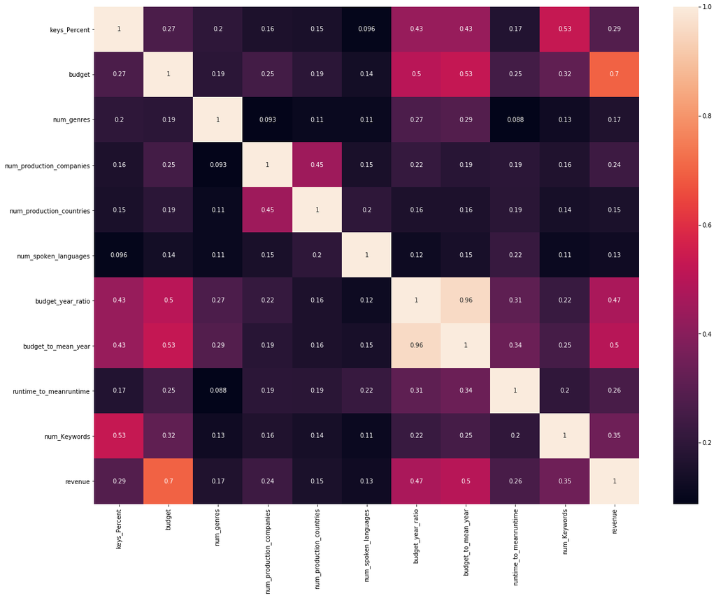

```python
signi_num_var = []  #11
for col in num_variable:
    p, f = pearsonr(tmp['revenue'], tmp[col])
    if p > .1:
        print(col)
        signi_num_var.append(col)

tmp1 = tmp[signi_num_var]
f,ax = plt.subplots(figsize=(20, 15))
sns.heatmap(tmp1.corr(), annot=True)
plt.show()
```

## 5.2 Categorical features

we have significant numerical variable. Lets find out significant categorical variable

```python
def anova_stat(df, a, b):
    F, p = stats.f_oneway(df[df[b] == 1][a],
                      df[df[b] == 0][a])
    return p
signi_cat_var = []    #21 features
for col in flag_variable:
    p = anova_stat(tmp, 'revenue', col)
    if p < .05:
        print(col)
        signi_cat_var.append(col)

complete_variable_list = signi_num_var + signi_cat_var
final_data = tmp[complete_variable_list]     #32 total features
```

```
Drama_genre
Comedy_genre
Thriller_genre
Action_genre
Romance_genre
Adventure_genre
Crime_genre
Science Fiction_genre
Horror_genre
Family_genre
Fantasy_genre
Mystery_genre
Animation_genre
War_genre
Documentary_genre
Foreign_genre
TV Movie_genre
has_homepage
eng_language
isMovieReleased
USholidayreleased
```

# 6. Modelling

## 6.1 Modelling with missing values in Revenue

In this section we are going to use following model :

1. linear regression
2. random forest baseline & bayesian optimize random forest
3. xgboost baseline & bayesian optimize xgboost
4. lightgbm baseline & bayesian optimize lightgbm

```python
X = final_data.drop('revenue', axis = 1)
y = final_data['revenue']
X_train, X_test, y_train, y_test = train_test_split(X, y, test_size=0.20, random_state=123)
```

### 6.1.1 Linear Regression

```python
from sklearn.linear_model import LinearRegression

reg = LinearRegression()
reg.fit(X_train, y_train)
y_pred = reg.predict(X_test)
print('The rmse of prediction of baseline linear regression is :', sqrt(mean_squared_error(y_test, y_pred)))
linear_regression = sqrt(mean_squared_error(y_test, y_pred))
```

```
The rmse of prediction of baseline linear regression is : 5.542587567809025
```

### 6.1.2 Random Forest

```python
rf = RandomForestRegressor(random_state=123)
rf.fit(X_train, y_train)
y_pred = rf.predict(X_test)

print('The rmse of prediction of baseline randomforest is :', sqrt(mean_squared_error(y_test, y_pred)))
random_forest = sqrt(mean_squared_error(y_test, y_pred))


#Bayesian optimization
def bayesian_optimization(dataset, function, parameters):


    X_train, y_train, X_test, y_test = dataset
    n_iterations = 30
    gp_params = {"alpha": 1e-4}
    init_points = 12

    BO = BayesianOptimization(function, parameters)
    BO.maximize(n_iter=n_iterations, **gp_params, init_points = init_points)

    return BO.max

## for randomforest
def rfc_optimization(cv_splits):
    def function(n_estimators, max_depth, min_samples_split, max_features, min_samples_leaf): # make changes here to add more parameters

        return cross_val_score(
               RandomForestRegressor(
                   n_estimators=int(max(n_estimators,0)),
                   max_depth=int(max(max_depth,1)),
                   min_samples_split=int(max(min_samples_split,2)),
                   max_features = float(max(max_features,0.2)),
                   min_samples_leaf= int(max(min_samples_leaf,50)),
                   #oob_score = True,


                   n_jobs=-1,
                   random_state=22
                   ),
               X=X_train,
               y=y_train,
               cv=cv_splits,
               scoring="neg_mean_squared_error",
               n_jobs=-1).mean()

    parameters = {"n_estimators": (100, 1000),
                  "max_depth": (1, 200), #quick note : consider 1 to 200 next time
                  "min_samples_split": (2, 15),
                  "max_features": (0.2, 1),
                  "min_samples_leaf": (50, 100),
                  #"oob_score": True

                 }

    return function, parameters

#Train model using optimum parameters
def rftrain(X_train, y_train, X_test, y_test, function, parameters):
    dataset = (X_train, y_train, X_test, y_test)
    cv_splits = 10

    best_solution = bayesian_optimization(dataset, function, parameters)
    params = best_solution["params"]

    model = RandomForestRegressor(
             n_estimators=int(max(params["n_estimators"], 0)),
             max_depth=int(max(params["max_depth"], 1)),
             min_samples_split=int(max(params["min_samples_split"], 2)),
             max_features = float(max(params["max_features"], 0.2)),
             min_samples_leaf= int(max(params["min_samples_leaf"],50)),
             n_jobs=-1,
             random_state=23,
             #oob_score = True
             )

    model.fit(X_train, y_train)

    return model


rffunc, rfparams = rfc_optimization(10)
rfmodel = rftrain(X_train, y_train, X_test, y_test, rffunc, rfparams)



y_pred = rfmodel.predict(X_test)
print('The rmse of optimize random forest is:', sqrt(mean_squared_error(y_test, y_pred)))
opt_random_forest = sqrt(mean_squared_error(y_test, y_pred))
```

```
The rmse of prediction of baseline randomforest is : 5.762243074407854
|   iter    |  target   | max_depth | max_fe... | min_sa... | min_sa... | n_esti... |
-------------------------------------------------------------------------------------
|  1        | -30.05    |  68.63    |  0.2549   |  62.85    |  4.431    |  267.3    |
|  2        | -29.86    |  192.4    |  0.5538   |  63.4     |  8.102    |  669.3    |
|  3        | -30.14    |  80.03    |  0.438    |  99.66    |  12.63    |  835.9    |
|  4        | -30.03    |  22.17    |  0.7087   |  80.04    |  10.28    |  142.2    |
|  5        | -30.1     |  104.6    |  0.2463   |  68.64    |  8.729    |  776.9    |
|  6        | -29.76    |  103.1    |  0.5177   |  51.93    |  4.381    |  959.7    |
|  7        | -29.92    |  7.11     |  0.3712   |  66.84    |  9.727    |  598.4    |
|  8        | -29.96    |  66.46    |  0.2882   |  60.36    |  5.473    |  326.4    |
|  9        | -29.9     |  161.4    |  0.3305   |  64.12    |  9.143    |  279.7    |
|  10       | -29.76    |  16.83    |  0.3285   |  50.25    |  4.007    |  111.0    |
|  11       | -30.1     |  131.2    |  0.3328   |  90.64    |  11.93    |  515.3    |
|  12       | -29.79    |  120.2    |  0.5699   |  54.5     |  9.993    |  234.1    |
|  13       | -29.81    |  200.0    |  1.0      |  50.0     |  2.0      |  100.0    |
|  14       | -30.15    |  200.0    |  1.0      |  100.0    |  15.0     |  1e+03    |
|  15       | -35.9     |  1.0      |  1.0      |  50.0     |  15.0     |  1e+03    |
|  16       | -29.98    |  155.1    |  0.2      |  51.06    |  2.0      |  917.5    |
|  17       | -29.95    |  114.0    |  0.2      |  50.0     |  2.0      |  129.6    |
|  18       | -30.08    |  196.9    |  1.0      |  89.02    |  15.0     |  186.1    |
|  19       | -30.11    |  99.57    |  0.9663   |  96.75    |  13.75    |  643.4    |
|  20       | -29.8     |  9.313    |  0.4654   |  55.73    |  6.982    |  482.0    |
|  21       | -35.93    |  1.0      |  1.0      |  100.0    |  15.0     |  397.9    |
|  22       | -29.85    |  21.81    |  0.2969   |  56.94    |  6.608    |  116.6    |
|  23       | -29.88    |  32.04    |  0.2493   |  50.0     |  4.857    |  533.5    |
|  24       | -30.15    |  135.6    |  1.0      |  100.0    |  2.0      |  956.9    |
|  25       | -30.15    |  110.3    |  1.0      |  100.0    |  2.0      |  185.0    |
|  26       | -30.55    |  157.7    |  0.2      |  100.0    |  15.0     |  100.0    |
|  27       | -29.96    |  130.2    |  0.2      |  50.0     |  2.0      |  338.3    |
|  28       | -29.96    |  162.4    |  0.2      |  50.0     |  2.0      |  597.1    |
|  29       | -30.15    |  185.9    |  1.0      |  100.0    |  15.0     |  740.8    |
|  30       | -29.97    |  27.13    |  0.2      |  50.0     |  2.0      |  686.3    |
|  31       | -29.97    |  123.1    |  0.2      |  50.0     |  2.0      |  697.3    |
|  32       | -30.94    |  3.969    |  1.0      |  100.0    |  15.0     |  757.5    |
|  33       | -29.97    |  187.4    |  0.2      |  50.0     |  2.0      |  825.6    |
|  34       | -29.97    |  200.0    |  0.2      |  50.0     |  2.0      |  444.3    |
|  35       | -30.15    |  200.0    |  1.0      |  100.0    |  15.0     |  365.3    |
|  36       | -29.81    |  200.0    |  1.0      |  50.0     |  15.0     |  526.9    |
|  37       | -30.15    |  200.0    |  1.0      |  100.0    |  15.0     |  586.6    |
|  38       | -41.4     |  1.0      |  0.2      |  50.0     |  2.0      |  210.4    |
|  39       | -29.82    |  111.4    |  0.3925   |  58.75    |  6.948    |  287.0    |
|  40       | -30.11    |  121.7    |  0.3399   |  93.77    |  2.652    |  255.5    |
|  41       | -29.87    |  147.7    |  0.4334   |  65.28    |  6.162    |  649.0    |
|  42       | -30.14    |  9.391    |  1.0      |  98.63    |  5.181    |  102.2    |
=====================================================================================
The rmse of optimize random forest is: 5.37507363211807
```

### 6.1.3 XGBoost

```
[14:47:10] WARNING: C:/Jenkins/workspace/xgboost-win64_release_0.90/src/objective/regression_obj.cu:152: reg:linear is now deprecated in favor of reg:squarederror.
The rmse of XGBoost Baseline is : 5.336937873384235
```

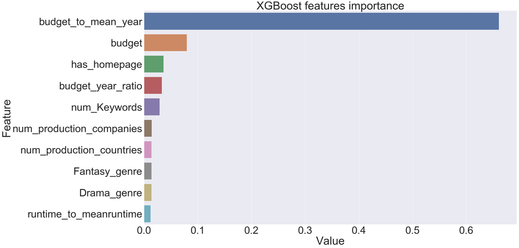

```
|   iter    |  target   |    eta    |   gamma   | max_depth | min_ch... | n_esti... |
-------------------------------------------------------------------------------------
|  1        | -29.42    |  0.18     |  0.031    |  1.668    |  8.652    |  97.42    |
|  2        | -29.89    |  0.1536   |  1.406    |  5.472    |  4.314    |  91.54    |
|  3        | -31.78    |  0.1935   |  1.274    |  8.166    |  2.791    |  111.5    |
|  4        | -30.05    |  0.09477  |  0.7998   |  6.726    |  7.375    |  65.68    |
|  5        | -30.02    |  0.1537   |  0.5327   |  5.047    |  2.869    |  134.0    |
|  6        | -29.53    |  0.1418   |  0.9644   |  1.679    |  3.91     |  96.46    |
|  7        | -29.93    |  0.1306   |  0.04364  |  1.903    |  9.697    |  52.74    |
|  8        | -30.13    |  0.143    |  0.6596   |  6.756    |  8.248    |  81.1     |
|  9        | -30.18    |  0.1614   |  0.896    |  6.235    |  7.411    |  83.16    |
|  10       | -29.39    |  0.08229  |  0.5509   |  2.767    |  7.253    |  103.5    |
|  11       | -30.13    |  0.1218   |  1.886    |  7.539    |  8.009    |  133.2    |
|  12       | -29.71    |  0.1837   |  0.5481   |  4.567    |  5.915    |  103.8    |
|  13       | -29.58    |  0.07     |  0.0      |  1.0      |  10.0     |  150.0    |
|  14       | -33.19    |  0.2      |  2.0      |  10.0     |  1.0      |  150.0    |
|  15       | -33.19    |  0.2      |  2.0      |  10.0     |  1.0      |  50.0     |
|  16       | -29.62    |  0.07     |  0.0      |  1.0      |  10.0     |  140.8    |
|  17       | -30.3     |  0.07     |  0.0      |  1.0      |  1.0      |  73.62    |
|  18       | -30.97    |  0.07     |  2.0      |  10.0     |  10.0     |  97.76    |
|  19       | -29.7     |  0.07     |  0.0      |  1.0      |  10.0     |  126.7    |
|  20       | -29.7     |  0.07     |  2.0      |  1.0      |  1.0      |  125.8    |
|  21       | -29.46    |  0.2      |  0.0      |  1.0      |  10.0     |  61.47    |
|  22       | -29.44    |  0.2      |  2.0      |  1.0      |  10.0     |  71.24    |
|  23       | -29.47    |  0.2      |  0.0      |  1.0      |  1.0      |  87.22    |
|  24       | -30.04    |  0.07     |  0.0      |  1.0      |  10.0     |  88.4     |
|  25       | -29.48    |  0.2      |  0.0      |  1.0      |  1.0      |  103.0    |
|  26       | -29.41    |  0.2      |  0.0      |  1.0      |  10.0     |  111.6    |
|  27       | -29.41    |  0.2      |  2.0      |  1.0      |  10.0     |  119.0    |
|  28       | -33.19    |  0.2      |  2.0      |  10.0     |  1.0      |  79.91    |
|  29       | -30.2     |  0.07     |  0.0      |  1.0      |  10.0     |  78.57    |
|  30       | -31.14    |  0.07     |  0.0      |  10.0     |  10.0     |  123.2    |
|  31       | -29.47    |  0.2      |  2.0      |  1.0      |  1.172    |  63.55    |
|  32       | -30.51    |  0.07     |  0.0      |  1.0      |  6.016    |  66.85    |
|  33       | -29.48    |  0.2      |  2.0      |  1.0      |  4.347    |  58.16    |
|  34       | -29.41    |  0.2      |  2.0      |  1.0      |  10.0     |  134.0    |
|  35       | -30.35    |  0.2      |  2.0      |  6.941    |  10.0     |  59.07    |
|  36       | -29.75    |  0.07     |  0.0      |  1.0      |  3.31     |  118.7    |
|  37       | -32.0     |  0.2      |  2.0      |  10.0     |  10.0     |  71.58    |
|  38       | -29.62    |  0.07     |  2.0      |  1.0      |  2.683    |  139.8    |
|  39       | -29.41    |  0.2      |  2.0      |  1.0      |  10.0     |  106.5    |
|  40       | -30.5     |  0.2      |  0.0      |  6.907    |  1.0      |  62.39    |
|  41       | -30.0     |  0.07     |  0.0      |  1.0      |  1.0      |  92.4     |
|  42       | -31.14    |  0.07     |  0.0      |  10.0     |  10.0     |  140.7    |
=====================================================================================
[14:51:05] WARNING: C:/Jenkins/workspace/xgboost-win64_release_0.90/src/objective/regression_obj.cu:152: reg:linear is now deprecated in favor of reg:squarederror.
The rmse of optimize XGBoost is : 5.331512646202879
```

```python
model = xgb.XGBRegressor()
model.fit(X_train, y_train)
y_pred = model.predict(X_test)
print('The rmse of XGBoost Baseline is :', sqrt(mean_squared_error(y_test, y_pred)))
xgboost = sqrt(mean_squared_error(y_test, y_pred))
feature_imp = pd.DataFrame(sorted(zip(model.feature_importances_,X_train.columns)),
                               columns=['Value','Feature'])
plt.figure(figsize=(40, 20))
sns.set(font_scale = 5)
sns.barplot(x="Value", y="Feature", data=feature_imp.sort_values(by="Value",
                                                        ascending=False)[0:10])
plt.title('XGBoost features importance')
plt.tight_layout()
plt.savefig('feaimp_xgb.png')
plt.show()
del feature_imp


## for XGB
eval_set = [(X_test, y_test)]
def xgb_optimization(cv_splits, eval_set):
    def function(eta, gamma, max_depth,n_estimators,min_child_weight):
            return cross_val_score(
                   xgb.XGBRegressor(
                       n_estimators=int(max(n_estimators,50)),
                       objective="reg:linear",
                       learning_rate=max(eta, 0),
                       gamma=max(gamma, 0),
                       max_depth=max(int(max_depth), 1),
                       min_child_weight=max(min_child_weight, 1),
                       #subsample = max(subsample, 0),
                       #colsample_bytree = max(colsample_bytree, 0),
                       #colsample_bylevel = max(colsample_bylevel, 0),

                       seed=42,
                       nthread=-1
                       ),
                   X=X_train,
                   y=y_train,
                   cv=cv_splits,
                   scoring='neg_mean_squared_error',
                   fit_params={
                        "early_stopping_rounds": 200,
                        "eval_metric": "rmse",
                        "eval_set": eval_set},
                   n_jobs=-1).mean()

    parameters = {"eta": (0.07, 0.2),
                  "gamma": (0,2),
                  "max_depth": (1, 10),
                 "min_child_weight": (1, 10),
                 #"subsample": (0,1),
                 #"colsample_bytree": (0,1),
                  "n_estimators": (50,150),
                  #"colsample_bylevel": (0,1)

                 }

    return function, parameters

#Train model using optimum parameters
def xgbtrain(X_train, y_train, X_test, y_test, function, parameters):
    dataset = (X_train, y_train, X_test, y_test)
    cv_splits = 10

    best_solution = bayesian_optimization(dataset, function, parameters)
    params = best_solution["params"]

    model = XGBRegressor(
             n_estimators=int(params["n_estimators"]),
             objective="reg:linear",
             learning_rate= params["eta"],
             gamma=int(params["gamma"]),
             max_depth=int(params["max_depth"]),
             min_child_weight=int(params["min_child_weight"]),
             #subsample=int(params["subsample"]),
             #colsample_bytree=int(params["colsample_bytree"]),
             #colsample_bylevel = int(params["colsample_bylevel"]),
             nthread=-1,
             seed=42
             )

    model.fit(X_train, y_train)

    return model


xgbfunction, xgbparameters = xgb_optimization(10, eval_set)
xgbmodel =xgbtrain(X_train, y_train, X_test, y_test, xgbfunction, xgbparameters)


y_pred = xgbmodel.predict(X_test)
print('The rmse of optimize XGBoost is :', sqrt(mean_squared_error(y_test, y_pred)))
opt_xgboost = sqrt(mean_squared_error(y_test, y_pred))
```